# ISA 401: Business Intelligence & Data Visualization

## 16: Fundamentals of Data Visualization (Cont.)

### Fall 2026

# Before We Start

1 Join today's game

Section A (8:30 AM)

[figure not shown]

isa401-game-day.vercel.app/?section=A

Section B (10:05 AM)

[figure not shown]

isa401-game-day.vercel.app/?section=B

Enter your **preferred first name** and **last initial**, then **tap your seat** (or **Joining remotely**).

The screen shows only your first name and seat. Points do not count toward your grade.

2 Join today's Zoom

Use the Zoom link in the [**Week 0 Module**](https://miamioh.instructure.com/courses/258169/modules/981092) on Canvas. **Mute** your mic and **turn off** your video.  
There is no R today. Your phone is enough.

3 Today's plan

**3 min.** Join the game.  
**12 min.** Finishing Wednesday: data types, encodings, color.  
**20 min.** The grammar of graphics.  
**20 min.** Game Day at Yager.  
**3 min.** The class project.  
**22 min.** Exam 01 review.

# Where We Are

ISA 401

↓

Phase I

**Data Acquisition & Transformation**  
Aug 24 to Oct 12 (ends with Exam 01)

Phase II (we are here)

**Data Visualization & Communication**  
Oct 14 to Nov 16 (ends with Exam 02)

Phase III

**Exploratory Data Mining & Project Synthesis**  
Nov 18 to Dec 2

**Today is the second class of Phase II.** On Wednesday we covered principles for good charts. Today we finish them and start writing charts as code.

Phase names and dates from the course schedule on [Canvas](https://miamioh.instructure.com/courses/258169).

# Learning Objectives

By the end of today, you should be able to:

1. **Apply** the grammar of graphics using ggplot2.

2. **Map** data types to visual encodings in code.

3. **Refine** charts with labels, scales, and themes.

4. **Critique** and improve draft visualizations.

... and finish Wednesday: data types, encodings, color.

# Part 1: Finishing Wednesday

# Notes From Wednesday

1 Correction: points vs. percent

Christians in the US: 77% (2009) to 65% (2018/2019).

The drop is **12 percentage points**, which is a **15.6% decline**. Our typed note on the Fox slide said "12% drop".

Values: [Pew Research Center (2019)](https://www.pewresearch.org/religion/2019/10/17/in-u-s-decline-of-christianity-continues-at-rapid-pace/).

2 Correction: Playfair's largest city

In our Playfair data, **London (1,100K)** is larger than **Constantinople (900K)**. London is the largest of the 22 cities.

Data: `data/playfair_data.csv`, from stat.uiowa.edu/~luke/data/Playfair.

3 Promised: where is the Fox chart's y-axis?

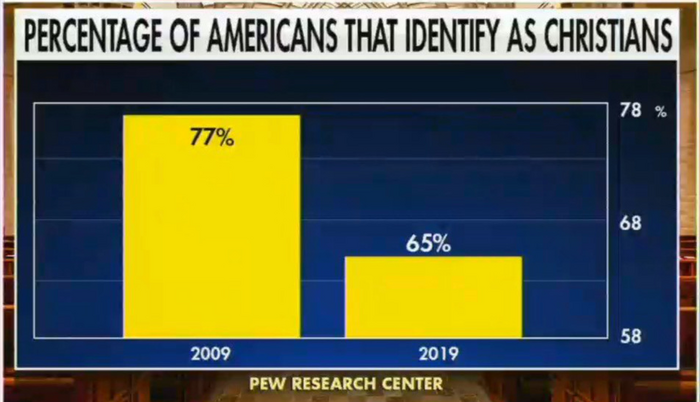

The y-axis labels (**58, 68, 78**) are on the **right** side of the chart. The axis starts at 58, not 0, so the 2019 bar looks less than half as tall as the 2009 bar.

Source: [this Fox News clip](https://video.foxnews.com/v/6274513508001).

# Data Types in One Slide

Nominal

Values are only **=** or **≠**.

Apples, bananas, oranges; jersey numbers.

**Test:** is jersey #22 "twice" jersey #11? **No.** The number is a label.

Ordinal

Values have an order (**<**), but the gaps are not equal amounts.

Survey ratings (poor, fair, good); finishing place (1st, 2nd, 3rd).

**Test:** is the gap from 1st to 2nd place the same as from 2nd to 3rd? **We cannot say.**

Interval

Differences mean something; the location of zero is arbitrary.

Temperature in °F or °C.

**Test:** is 40°F twice as warm as 20°F? **No,** but the 20°F difference is meaningful.

Ratio

Zero means none, so ratios, proportions, and differences all mean something.

Length, weight, counts.

**Test:** is a 40 lb bag twice as heavy as a 20 lb bag? **Yes.** 0 lb means no weight.

**Why it matters for charts:** a bar's length shows a value as a distance from zero. That works for ratio data. For interval data, a bar from zero has no meaning, so we use positions (dots, lines) instead.

Source: Stevens, S. S. (1946). [On the Theory of Scales of Measurement](https://doi.org/10.1126/science.103.2684.677). *Science*, 103(2684), 677-680.

# Data Terminology

<countdown-timer class="countdown" id="timer_f9121df5" minutes="2" seconds="0" update-every="1" tabindex="0" style="top:0;right:0;--countdown-font-size:2em;"></countdown-timer>

.panel[Task

**Task.** In 2 minutes, identify the data type (nominal, ordinal, interval, or ratio) of each column.

| Order ID | Order Date | Order Priority | Product Container | Product Cost | Ship Date |
| --- | --- | --- | --- | --- | --- |
| 1 | 1/1/2022 | 5 - low | Large box | 25 | 1/5/2022 |
| 2 | 1/4/2022 | 4 - not specified | Small Box | 36 | 1/7/2022 |
| 3 | 1/15/2022 | 2- high | Small Box | 38 | 1/17/2022 |
| 3 | 1/15/2022 | 2- high | Small Box | 41 | 1/17/2022 |
| 3 | 1/15/2022 | 2- high | Jumbo Box | 44 | 1/17/2022 |
| 3 | 1/15/2022 | 2- high | Wrap Bag | 33 | 1/17/2022 |
| 4 | 1/18/2022 | 1- urgent | Small Box | 33 | 1/19/2022 |
| 5 | 1/20/2022 | 3- medium | Medium Box | 40 | 1/23/2022 |
| 5 | 1/20/2022 | 3- medium | Small Box | 16 | 1/23/2022 |
| 5 | 1/20/2022 | 3- medium | Large box | 38 | 1/23/2022 |
| 6 | 1/21/2022 | 1- urgent | Wrap Bag | 7 | 1/22/2022 |

.panel[Your Answer

- Order ID: ________________
- Order Date / Ship Date: ________________
- Order Priority: ________________
- Product Container: ________________
- Product Cost: ________________

.panel[Answer

<details class="answer-gate">
<summary>Show the answer</summary>

<table>
<thead><tr><th>Column</th><th>Type</th><th>Why</th></tr></thead>
<tbody>
<tr><td>Order ID</td><td>Nominal</td><td>A label. Order 6 is not "more" than order 3, and averaging IDs means nothing.</td></tr>
<tr><td>Order Date, Ship Date</td><td>Interval</td><td>The difference (days to ship) is meaningful; a ratio of two dates is not. "Quantitative" is also accepted.</td></tr>
<tr><td>Order Priority</td><td>Ordinal</td><td>Urgent, high, medium, low has an order, but the gaps between levels are not equal amounts.</td></tr>
<tr><td>Product Container</td><td>Nominal or ordinal</td><td>Small, medium, large, and jumbo box have an order, so ordinal can be argued. A wrap bag has no place in that order, so with it in the column, nominal is the safer answer.</td></tr>
<tr><td>Product Cost</td><td>Ratio</td><td>$0 means no cost, so $40 is twice $20.</td></tr>
</tbody>
</table>

</details>

.panel[Discussion

# Data vs. Conceptual Models

1 Data model

32.5, 54.0, −17.3, ...

Numbers in a column.

→

2 Conceptual model

Temperature

What the numbers mean.

→

3 Data type we choose

Continuous to x significant digits: **quantitative**

Hot, warm, cold: **ordinal**

Burned vs. not burned: **nominal**

**The same column can become different data types,** depending on the question we ask. The type we choose decides which visual encodings fit.

# Mapping to Data Types

Bertin's visual (encoding) variables

[figure not shown]

Source: Bertin, J. (1967). *Sémiologie graphique*. Paris: Gauthier-Villars. English edition: [*Semiology of Graphics*](https://www.esri.com/en-us/esri-press/browse/semiology-of-graphics-diagrams-networks-maps) (Esri Press, 2010).

Which variables suit which data type

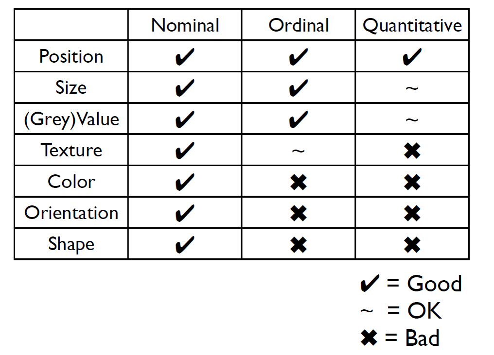

Source: adapted from Hanspeter Pfister, lecture notes for CS 171, Harvard University. [cs171.org](http://cs171.org/)

# Visual Channels and Their Precision

[figure not shown]

We perceive position more accurately than the other channels; area, angle, and color intensity are less precise.

Source: Franconeri, S. L., et al. (2021). [The Science of Visual Data Communication: What Works](https://doi.org/10.1177/15291006211051956). *Psychological Science in the Public Interest*, 22(3), 110-161.

# Color: Use It Sparingly

Simultaneous contrast

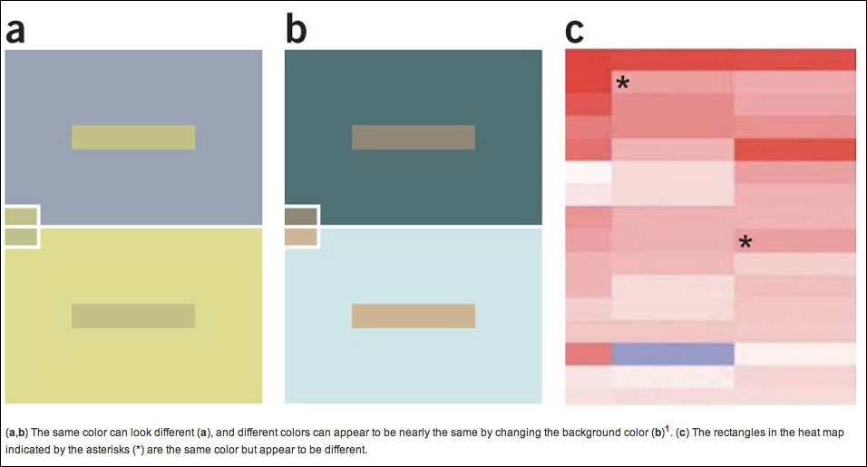

Source: adapted from Hanspeter Pfister, lecture notes for CS 171, Harvard University. [cs171.org](http://cs171.org/)

"About 1 in 12 men have color vision deficiency." ([National Eye Institute](https://www.nei.nih.gov/learn-about-eye-health/eye-conditions-and-diseases/color-blindness))

**Right, top row:** under simulated deuteranopia, the red / green palette turns the three species into similar olive browns. **Bottom row:** the Okabe-Ito palette keeps them apart.

Color vision deficiency

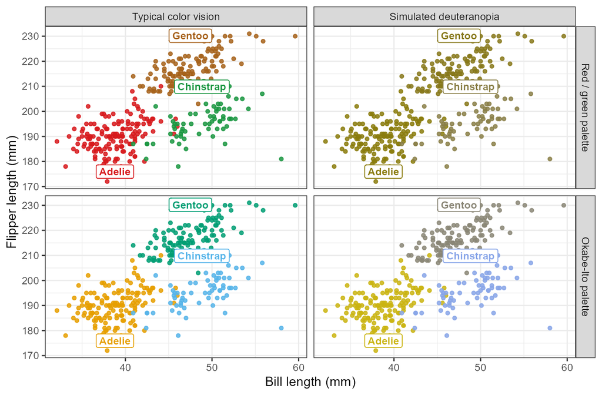

Data: `datasets::penguins` (Palmer Station LTER). Simulation: `colorspace::deutan()`.

# ColorBrewer: Choosing a Color Scale

[figure not shown]

**Pick a palette:** [colorbrewer2.org](https://colorbrewer2.org/) lets you choose the number of classes and the scheme type, and filter for colorblind-safe palettes.

Source: Brewer, C. A. (1999). Color Use Guidelines for Data Representation. *Proceedings of the Section on Statistical Graphics*, American Statistical Association, 55-60. The guidelines are built into [colorbrewer2.org](https://colorbrewer2.org/).

# Part 2: The Grammar of Graphics

# The Grammar of Graphics

The code appears on Step 1.

```
ggplot2::ggplot(data = region_totals,   # data  ggplot2::aes(x = "", y = population,  # aesthetics    fill = region)) +  ggplot2::geom_col() +                 # geometry  ggplot2::coord_cartesian() +          # coordinates  ggplot2::theme_void()                 # theme
```

```
ggplot2::ggplot(data = region_totals,   # data  ggplot2::aes(x = "", y = population,  # aesthetics    fill = region)) +  ggplot2::geom_col() +                 # geometry  ggplot2::coord_polar(theta = "y") +   # coordinates  ggplot2::theme_void()                 # theme
```

| region | cities | population (thousands) |
| --- | --- | --- |
| Northern Europe | 5 | 1,523 |
| Southern Europe | 9 | 1,365 |
| Western Europe | 4 | 1,310 |
| Western Asia | 1 | 900 |
| Eastern Europe | 3 | 510 |

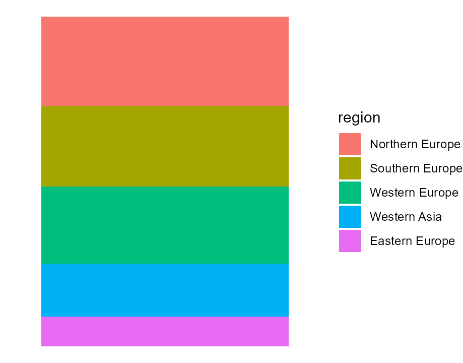

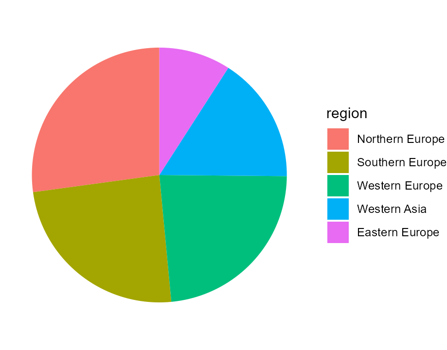

**The data:** the total population of Playfair's 22 cities in each region. A chart menu, as in Excel, offers a fixed list of chart types. The grammar of graphics describes a chart by its parts instead.

**A stacked bar.** Data, an aesthetic mapping (fill = region), a geometry (columns), and Cartesian coordinates.

**A pie.** Only the coordinates line changed. coord_polar() wraps the same bar around a circle: a pie chart is a stacked bar in polar coordinates.

0 / 2

Data: `data/playfair_data.csv`. The region column is ours, not Playfair's: the [UN M49](https://unstats.un.org/unsd/methodology/m49/) subregion of each city's present-day country (Istanbul is in Türkiye, which M49 places in Western Asia).

# The Layers of a Graphic

Data

Aesthetics

Geometries

Facets

Statistics

Coordinates

Theme

**A chart is built from layers.** Each layer answers one question about the chart. Press Step to stack them from the bottom up. The examples use Playfair's cities.

**Data.** Which table is the chart made from, and what is one row? Here, one row is one city.

```
ggplot2::ggplot(data = playfair)
```

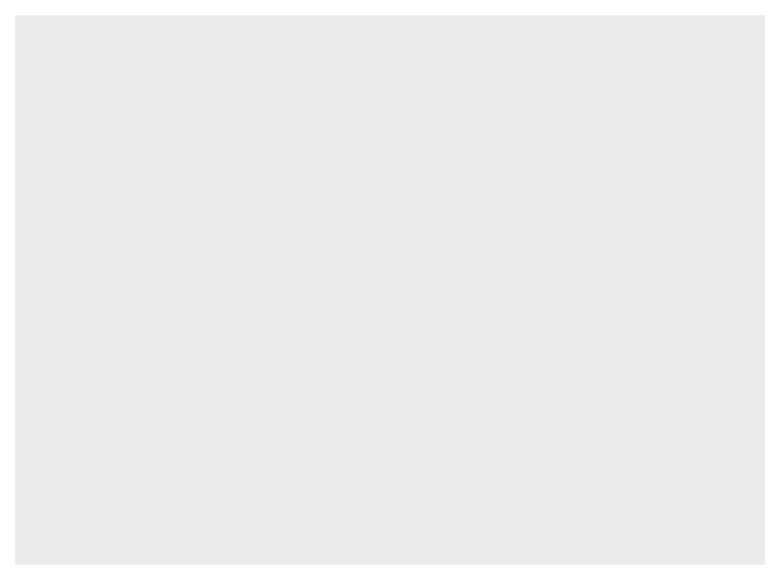

**Aesthetics.** Which column goes to which visual channel: x position, y position, color, size, shape. Scales then set how each mapping is drawn (which colors, which axis breaks).

```
ggplot2::aes(x = population, y = city)
```

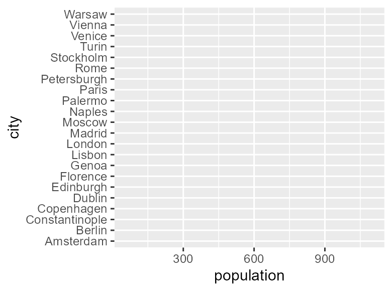

**Geometries.** The marks that show the data: points, lines, bars, text.

```
ggplot2::geom_point()
```

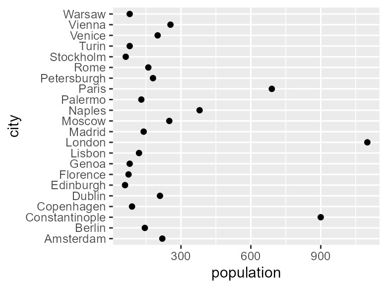

**Facets.** Small multiples: the same chart drawn once for each group.

```
ggplot2::facet_wrap(~ region)
```

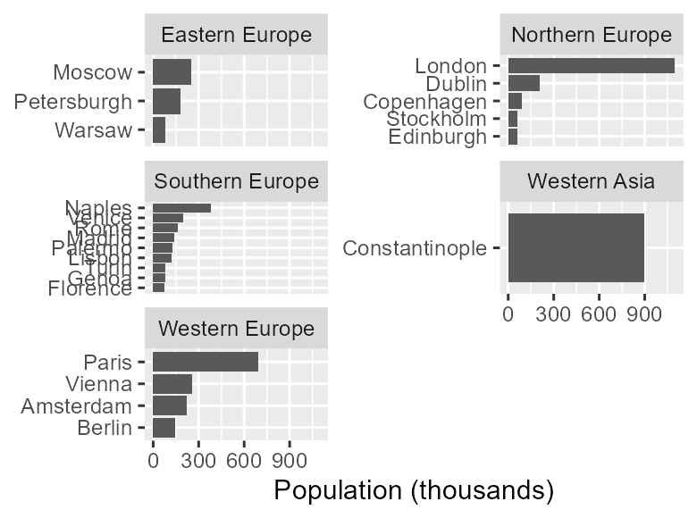

**Statistics.** A summary computed from the data before drawing, such as a count, a mean, or a fitted line. Here stat = "count" counts the cities in each region.

```
ggplot2::geom_bar(stat = "count")
```

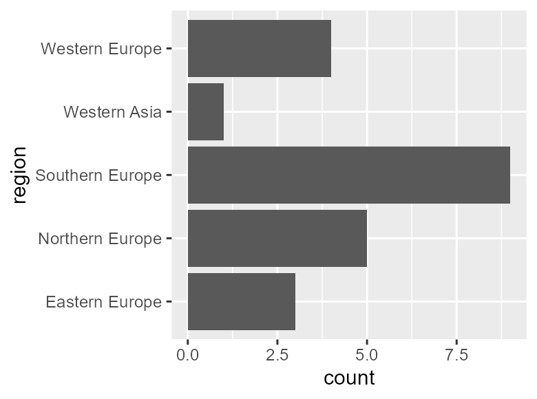

**Coordinates.** The space the marks are drawn in: Cartesian (x and y), polar (angle and radius), or a map projection.

```
ggplot2::coord_radial(theta = "y")
```

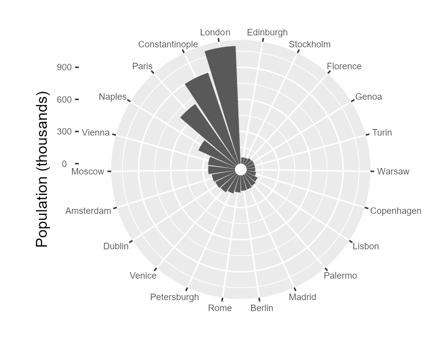

**Theme.** Everything that does not show data: background, grid lines, fonts, legend position.

```
ggplot2::theme_bw()
```

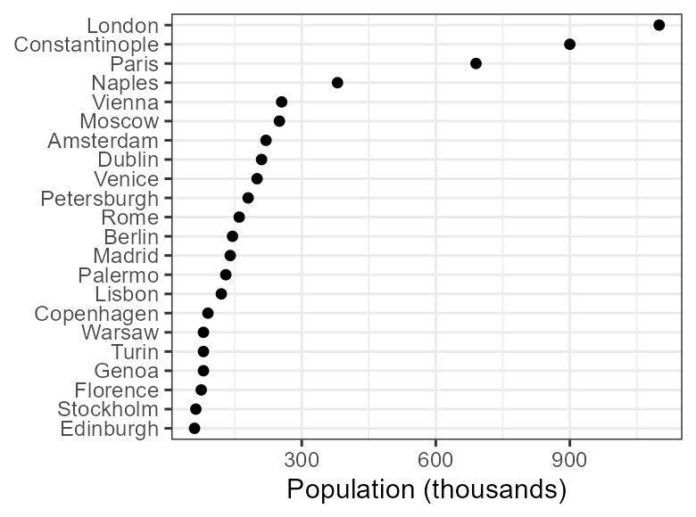

0 / 7

Sources: Wilkinson, L. (2005). [*The Grammar of Graphics*](https://doi.org/10.1007/0-387-28695-0) (2nd ed.). Springer. Wickham, H. (2010). [A Layered Grammar of Graphics](https://doi.org/10.1198/jcgs.2009.07098). *Journal of Computational and Graphical Statistics*, 19(1), 3-28. The seven-layer stack is a common teaching summary of these papers; "theme" is ggplot2's name for the non-data parts.

# One Template for Every Chart

The template

```
ggplot2::ggplot(data = <DATA>,  # data  ggplot2::aes(<MAPPINGS>)) +   # aesthetics  ggplot2::<GEOM_FUNCTION>()    # geometry
```

Filled in for Playfair's cities

```
ggplot2::ggplot(data = playfair,             # data  ggplot2::aes(x = population, y = city)) +  # aesthetics  ggplot2::geom_point()                      # geometry
```

Data

The table. One row per city: city, population, and region.

Aesthetics

Which column goes to which channel. Population to x, city to y.

Geometry

Which mark to draw. One point per row.

**These three layers are required.** Every other part (facets, statistics, coordinates, scales, theme) is added with **+** and has a default; labs() adds titles.

# Building Playfair's Dot Chart One Layer at a Time

The code appears on Step 1.

```
ggplot2::ggplot(data = playfair)  # data
```

```
ggplot2::ggplot(data = playfair,  # data  ggplot2::aes(x = population,    # aesthetics    y = city))
```

```
ggplot2::ggplot(data = playfair,  # data  ggplot2::aes(x = population,    # aesthetics    y = city)) +  ggplot2::geom_point()           # geometry
```

```
ggplot2::ggplot(data = playfair,  # data  ggplot2::aes(x = population,    # aesthetics    y = forcats::fct_reorder(city, population))) +  ggplot2::geom_point()           # geometry
```

```
ggplot2::ggplot(data = playfair,  # data  ggplot2::aes(x = population,    # aesthetics    y = forcats::fct_reorder(city, population))) +  ggplot2::geom_point() +         # geometry  ggplot2::labs(                  # labels    title = "Only three cities had over 500,000 people",    x = "Population (thousands)", y = NULL)
```

```
ggplot2::ggplot(data = playfair,  # data  ggplot2::aes(x = population,    # aesthetics    y = forcats::fct_reorder(city, population))) +  ggplot2::geom_point() +         # geometry  ggplot2::labs(                  # labels    title = "Only three cities had over 500,000 people",    x = "Population (thousands)", y = NULL) +  ggplot2::theme_bw()             # theme
```

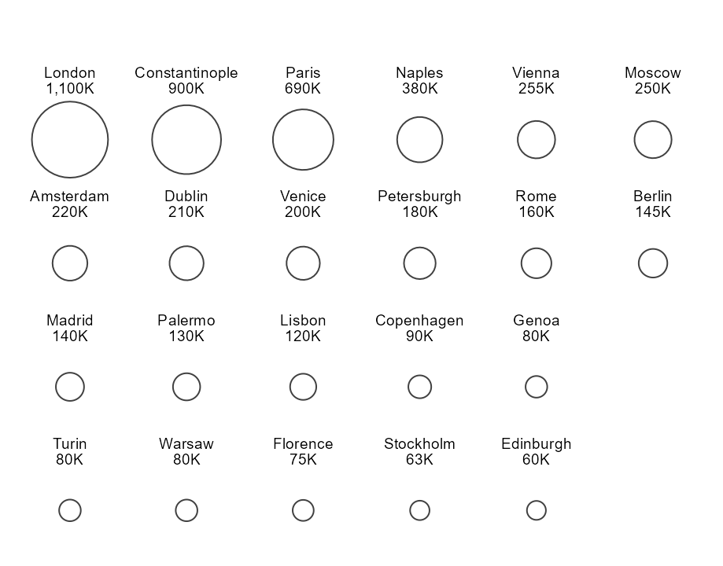

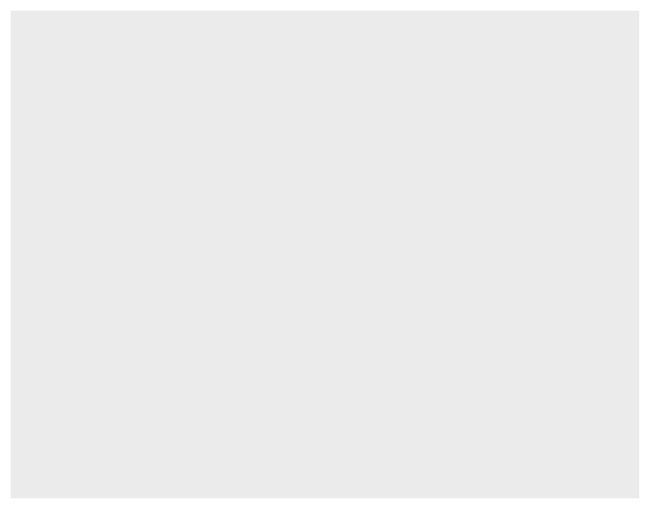

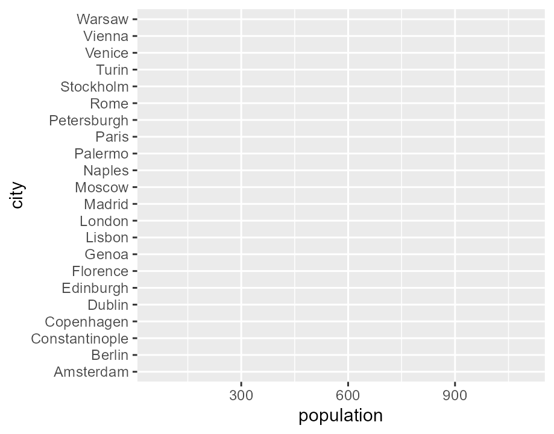

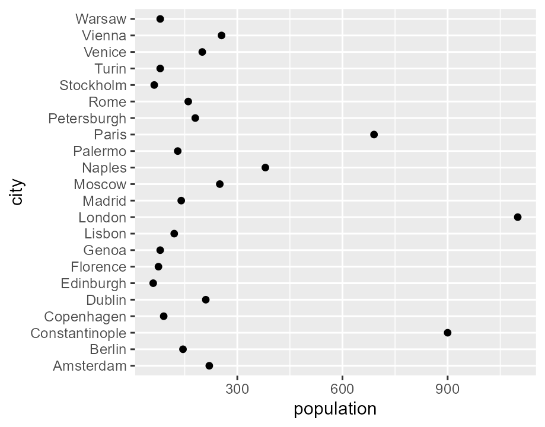

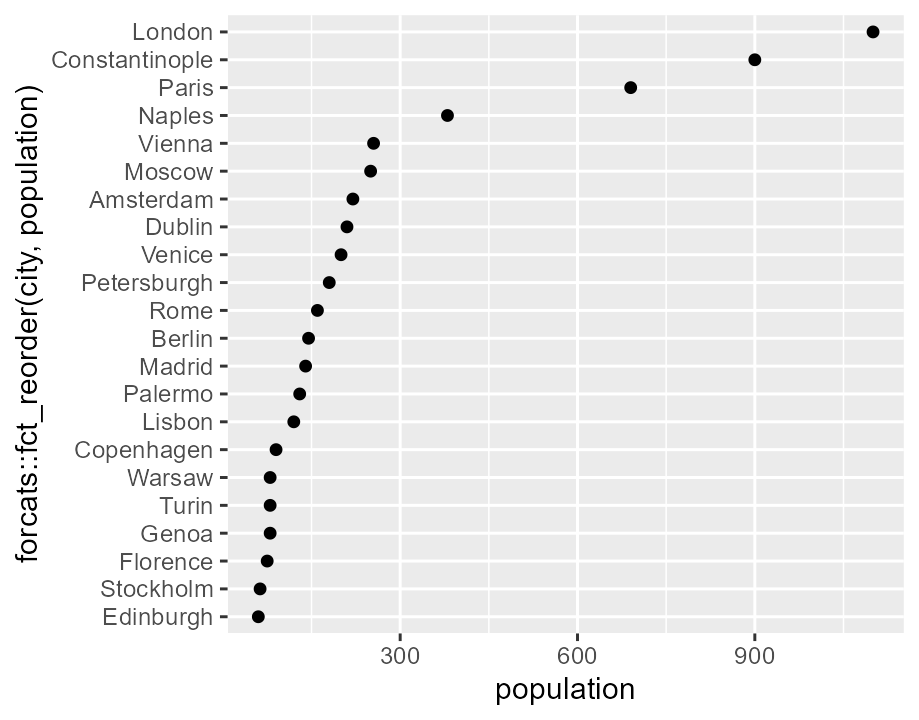

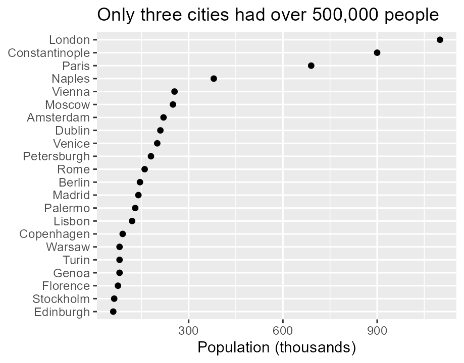

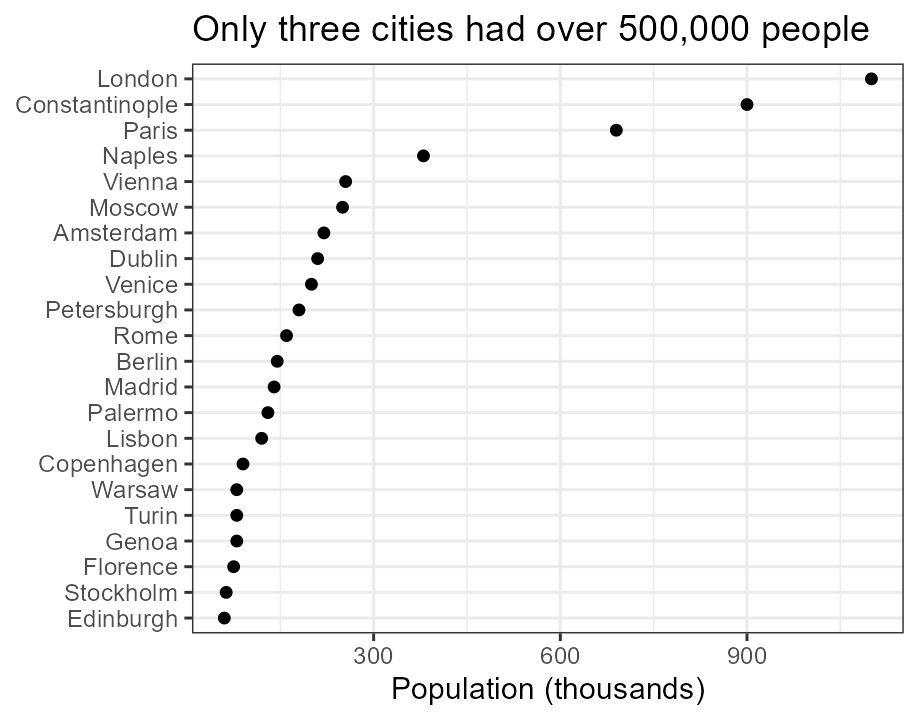

**Wednesday's task:** draw a better chart than Playfair's bubbles. Here we build one with the grammar, one layer at a time.

**Data.** ggplot() gets the table but no mappings, so it draws an empty canvas.

**Aesthetics.** Population goes to the x position and city to the y position. The axes appear, but nothing is drawn: there is no geometry yet.

**Geometry.** geom_point() draws one point per row (22 cities). The cities are in alphabetical order, so the ranking is hard to read.

**Reorder.** fct_reorder() sorts the cities by population. This changes the y aesthetic; the data are unchanged.

**Labels.** The title states the finding. The x-axis label gives the unit, and y = NULL removes the y-axis title, which showed the code.

**Theme.** theme_bw() changes the parts that do not show data: a white background and gray grid lines. This is the dot chart behind Wednesday's My Solution tab.

0 / 6

Data: `data/playfair_data.csv` (population in thousands), from stat.uiowa.edu/~luke/data/Playfair.

# Mapping vs. Setting

```
ggplot2::ggplot(data = playfair,                    # data  ggplot2::aes(x = population,                      # aesthetics    y = forcats::fct_reorder(city, population))) +  ggplot2::geom_point() +                           # geometry  ggplot2::labs(                                    # labels    title = "Only three cities had over 500,000 people",    x = "Population (thousands)", y = NULL) +  ggplot2::theme_bw()                               # theme
```

```
ggplot2::ggplot(data = playfair,                    # data  ggplot2::aes(x = population,                      # aesthetics    y = forcats::fct_reorder(city, population))) +  ggplot2::geom_point(                              # geometry    ggplot2::aes(color = region)) +  ggplot2::labs(                                    # labels    title = "Only three cities had over 500,000 people",    x = "Population (thousands)", y = NULL) +  ggplot2::theme_bw()                               # theme
```

```
ggplot2::ggplot(data = playfair,                    # data  ggplot2::aes(x = population,                      # aesthetics    y = forcats::fct_reorder(city, population))) +  ggplot2::geom_point(                              # geometry    ggplot2::aes(color = region)) +  ggplot2::scale_color_brewer(palette = "Dark2") +  # scales  ggplot2::labs(                                    # labels    title = "Only three cities had over 500,000 people",    x = "Population (thousands)", y = NULL) +  ggplot2::theme_bw()                               # theme
```

```
ggplot2::ggplot(data = playfair,                    # data  ggplot2::aes(x = population,                      # aesthetics    y = forcats::fct_reorder(city, population))) +  ggplot2::geom_point(color = "#C3142D") +          # geometry  ggplot2::labs(                                    # labels    title = "Only three cities had over 500,000 people",    x = "Population (thousands)", y = NULL) +  ggplot2::theme_bw()                               # theme
```

```
ggplot2::ggplot(data = playfair,                    # data  ggplot2::aes(x = population,                      # aesthetics    y = forcats::fct_reorder(city, population))) +  ggplot2::geom_point(                              # geometry    ggplot2::aes(color = "#C3142D")) +  ggplot2::labs(                                    # labels    title = "Only three cities had over 500,000 people",    x = "Population (thousands)", y = NULL) +  ggplot2::theme_bw()                               # theme
```

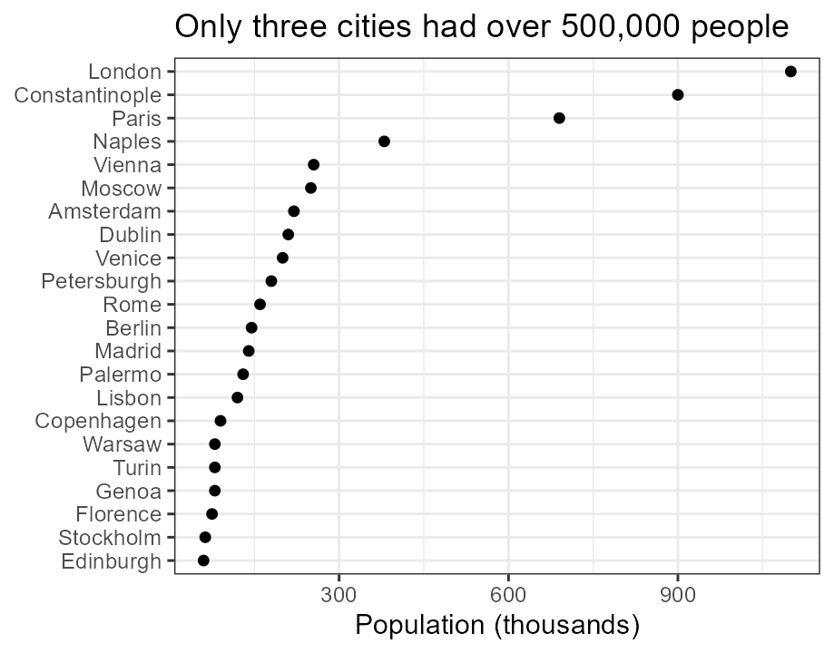

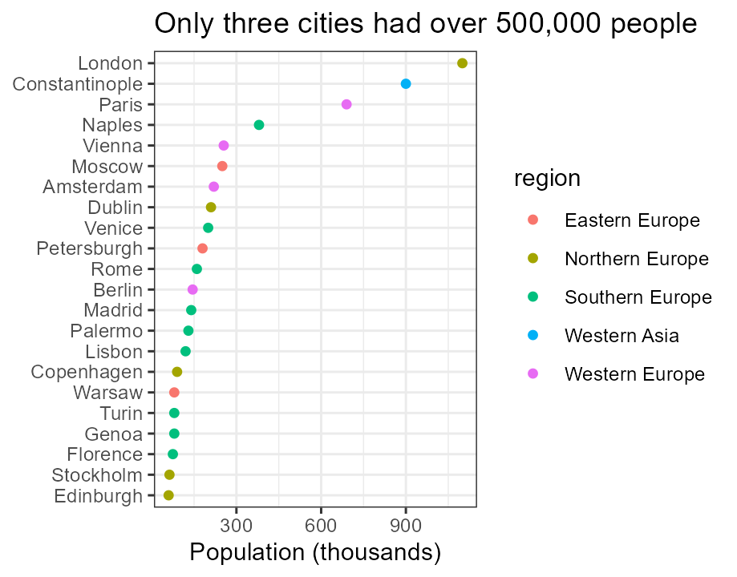

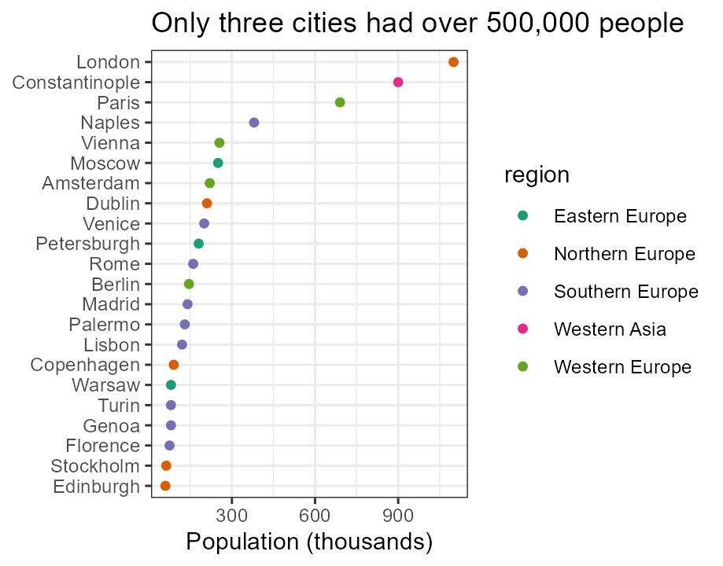

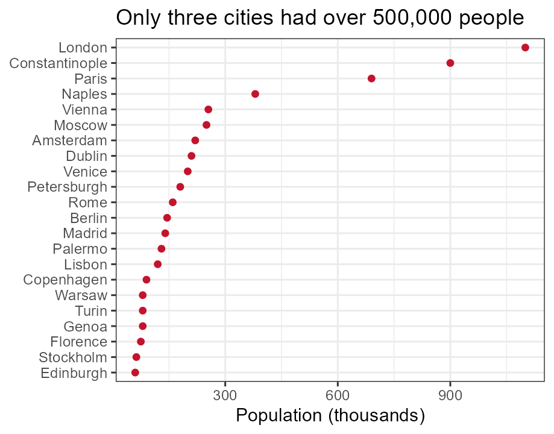

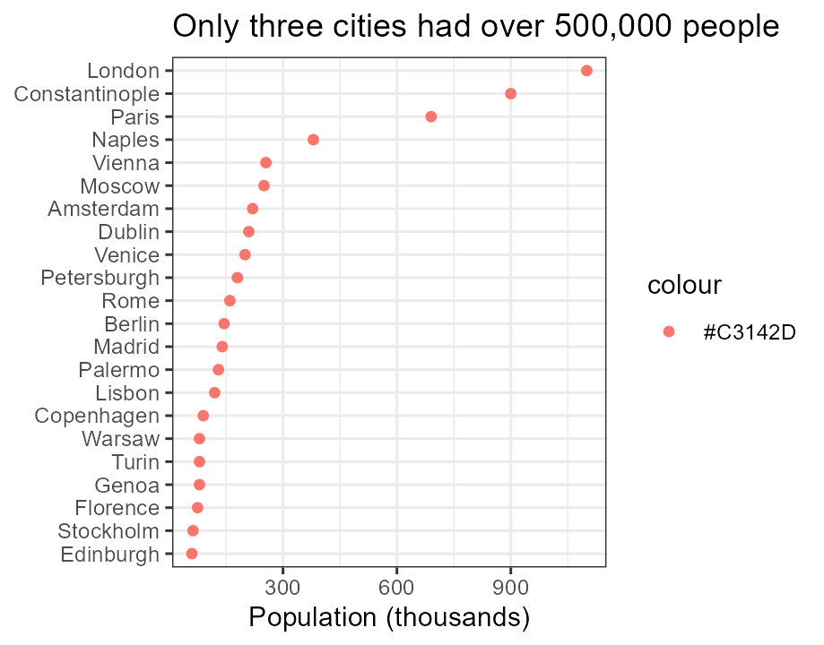

**The chart we just built.** There are two ways to give the points a color: map a variable to color, or set one color for all points.

**Mapping.** Inside aes(), color = region maps a nominal variable to color. ggplot2 picks one color per region and adds a legend.

**Scales.** scale_color_brewer() uses a ColorBrewer qualitative palette (Dark2), which suits a nominal variable such as region.

**Setting.** Outside aes(), color = "#C3142D" gives every point the same color. No variable is involved, so there is no legend.

**A common mistake.** Inside aes(), "#C3142D" is treated as data: a variable with one value. ggplot2 colors that value with its first default color (not Miami red) and adds a legend.

0 / 4

Region: the [UN M49](https://unstats.un.org/unsd/methodology/m49/) subregion of each city's present-day country (our addition to Playfair's data). #C3142D is Miami red.

# Changing One Layer Changes the Chart

```
ggplot2::ggplot(data = playfair,           # data  ggplot2::aes(x = population,             # aesthetics    y = forcats::fct_reorder(city, population))) +  ggplot2::geom_col() +                    # geometry  ggplot2::coord_cartesian() +             # coordinates  ggplot2::labs(x = "Population (thousands)", y = NULL)
```

```
ggplot2::ggplot(data = playfair,           # data  ggplot2::aes(x = population,             # aesthetics    y = forcats::fct_reorder(city, population))) +  ggplot2::geom_point() +                  # geometry  ggplot2::coord_cartesian() +             # coordinates  ggplot2::labs(x = "Population (thousands)", y = NULL)
```

```
ggplot2::ggplot(data = playfair,           # data  ggplot2::aes(x = population,             # aesthetics    y = forcats::fct_reorder(city, population))) +  ggplot2::geom_col() +                    # geometry  ggplot2::coord_radial(theta = "y") +     # coordinates  ggplot2::labs(x = "Population (thousands)", y = NULL)
```

```
ggplot2::ggplot(data = playfair,           # data  ggplot2::aes(x = population,             # aesthetics    y = forcats::fct_reorder(city, population))) +  ggplot2::geom_col() +                    # geometry  ggplot2::coord_cartesian() +             # coordinates  ggplot2::facet_wrap(~ region, ncol = 2,  # facets    scales = "free_y") +  ggplot2::labs(x = "Population (thousands)", y = NULL)
```

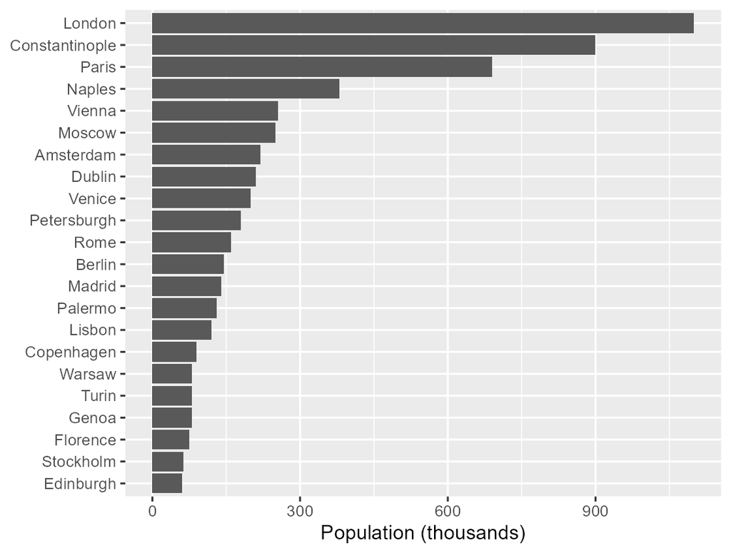

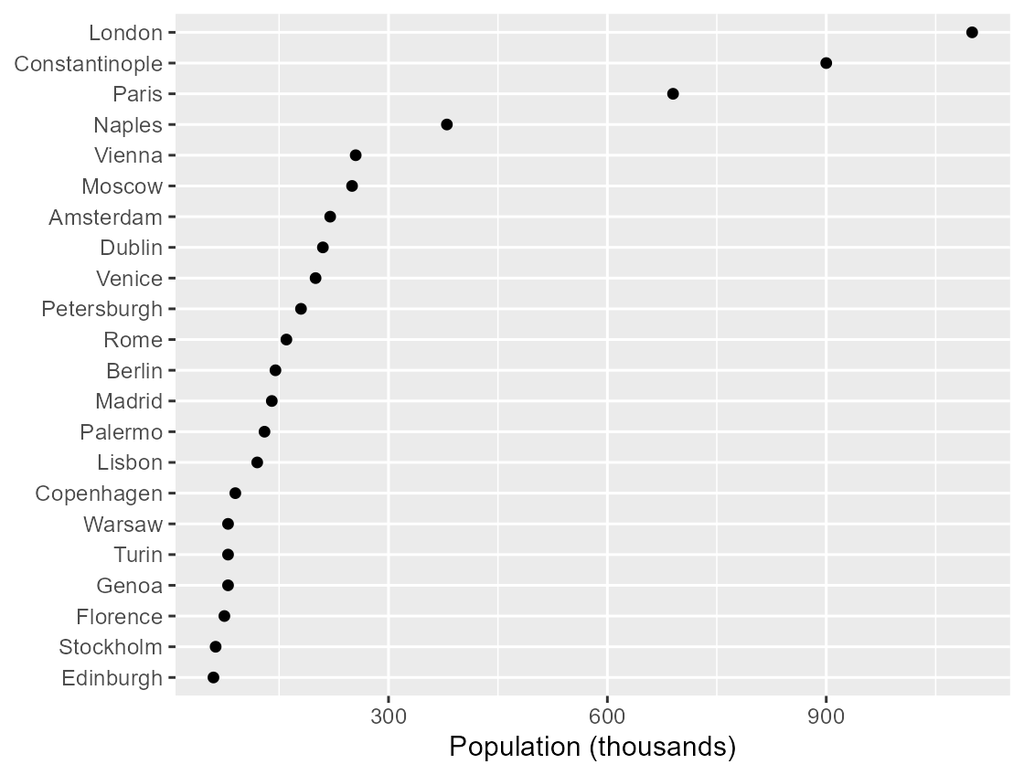

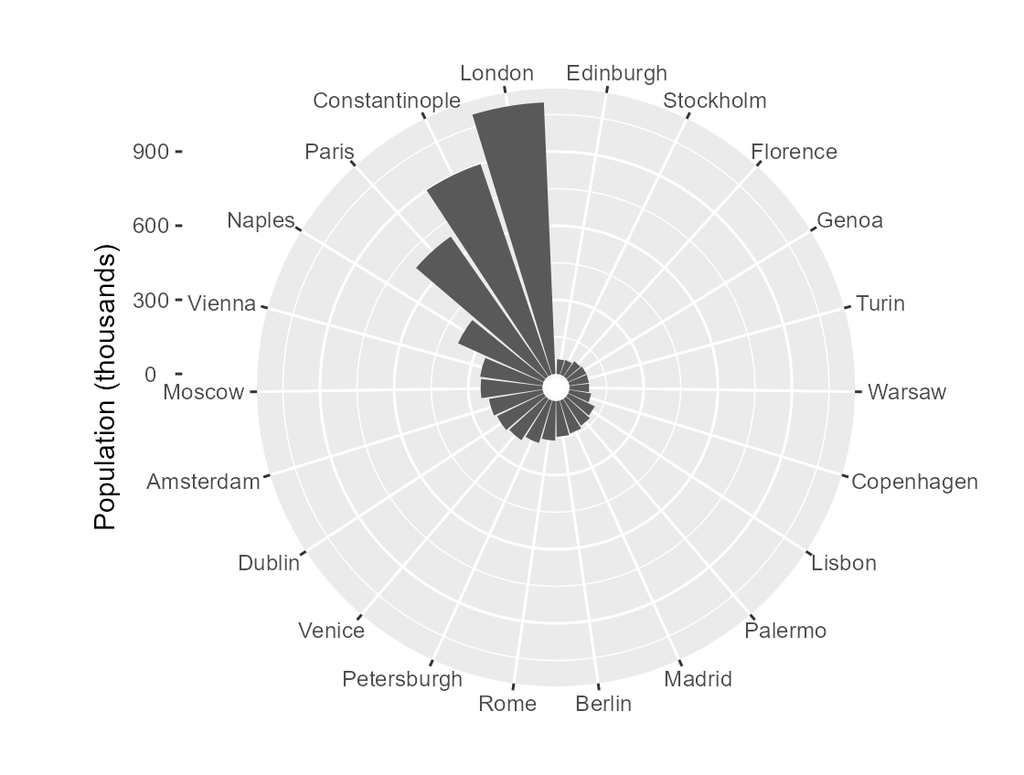

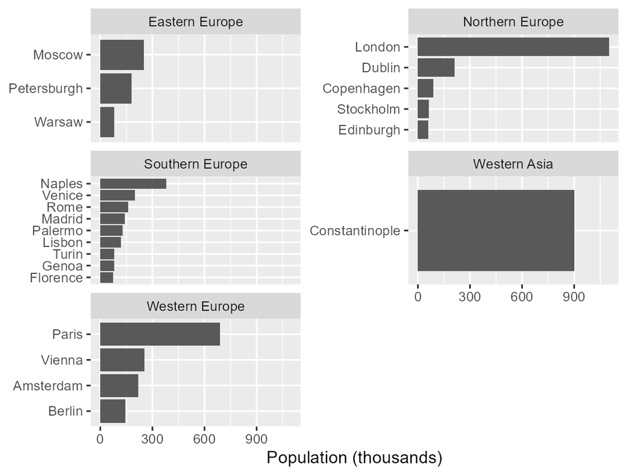

**The starting chart:** bars (geom_col) in Cartesian coordinates. Each step changes one line of this code.

**Geometry.** geom_col() becomes geom_point(). Same data and mappings; points instead of bars.

**Coordinates.** coord_cartesian() becomes coord_radial(), ggplot2's polar coordinate system. Each city gets an angle, and population is the distance from the center.

**Facets.** facet_wrap(~ region) adds one panel per region. scales = "free_y" keeps only each region's cities in its panel.

0 / 3

Data: `data/playfair_data.csv` (population in thousands), from stat.uiowa.edu/~luke/data/Playfair. Region: the [UN M49](https://unstats.un.org/unsd/methodology/m49/) subregion of each city's present-day country (our addition).